r = linspace(0,1,41);

theta = linspace(0,2*pi,81);

[R,Theta] = ndgrid(r,theta);

F = 1-R.^4;

surf(R,Theta,F)

shading flat % ignore this line

xlabel('r'), ylabel('\theta'), title('A polar function') % ignore this line

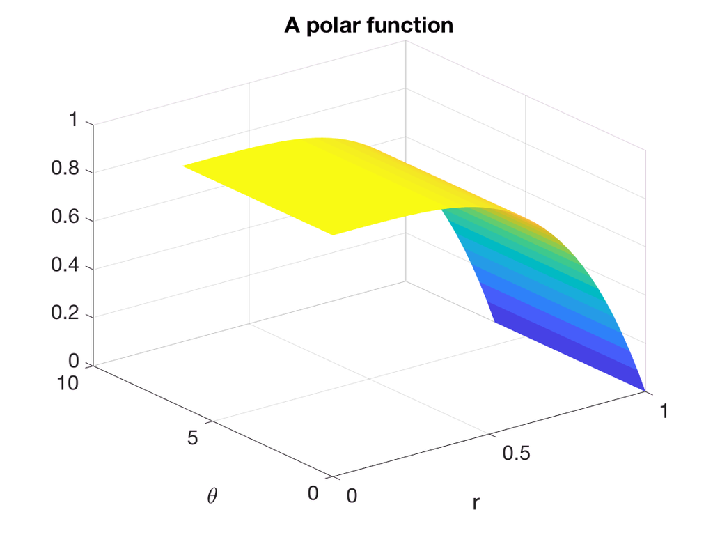

Of course we are used to seeing such plots over the plane. This is easily accomplished.

X = R.*cos(Theta); Y = R.*sin(Theta);

surf(X,Y,F)

shading flat % ignore this line

xlabel('x'), ylabel('y'), title('Function over the unit disk') % ignore this line

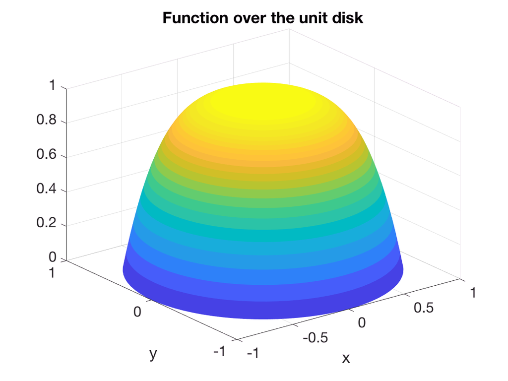

theta = linspace(0,2*pi,61);

phi = linspace(0,pi,61);

[Theta,Phi] = ndgrid(theta,phi);

X = cos(Theta).*sin(Phi); Y = sin(Theta).*sin(Phi);

Z = cos(Phi);

F = X.*Y.*Z.^3;

surf(X,Y,Z,F), colorbar

axis equal, shading flat % ignore this line

xlabel('x'), ylabel('y'), zlabel('z') % ignore this line

title('Function on the unit sphere') % ignore this line

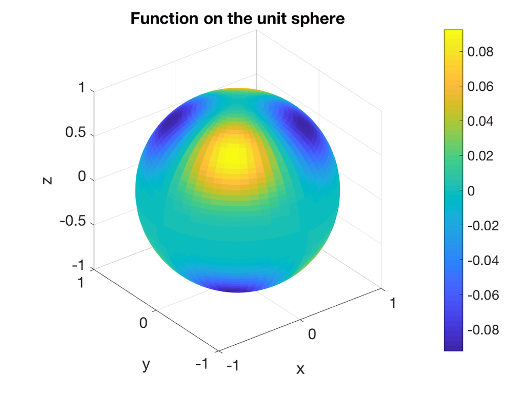